# Statistical summaries

# The old faithful geyser

```r
library(tidyverse)
```

The [Old Faithful](https://en.wikipedia.org/wiki/Old_Faithful) is a geyser in Yellowstone park, famous for erupting at pretty regular intervals. `R` comes with the `faithful` dataset containing information about the eruption durations (`eruptions` column) and the waiting time between eruptions (`waiting` column).

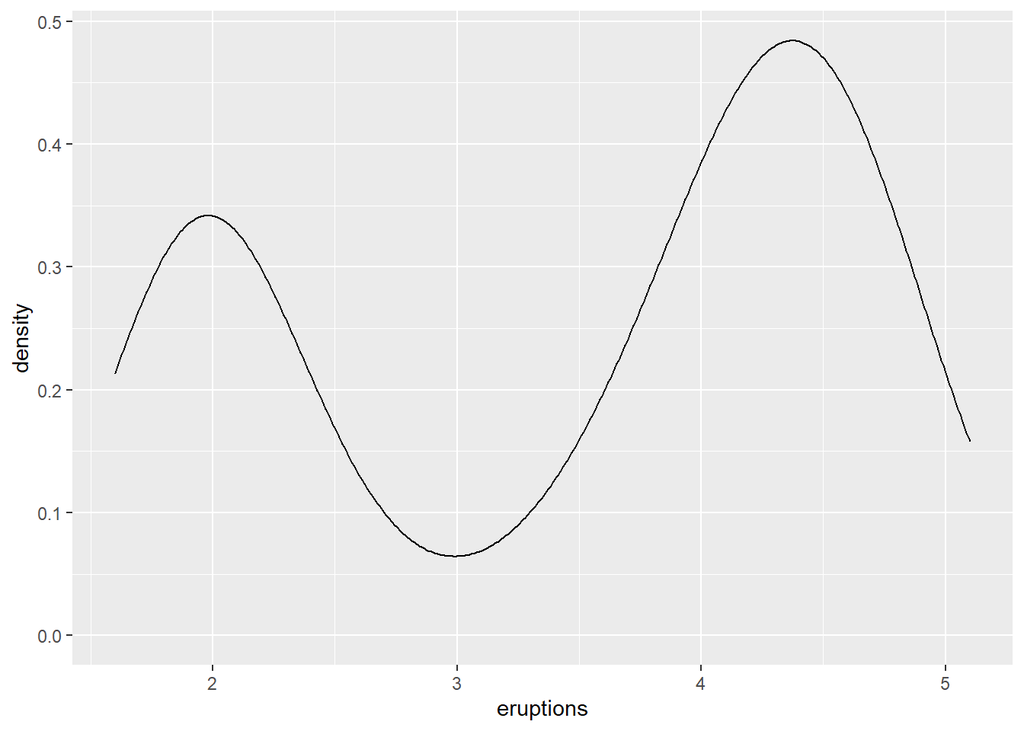

```r
# Your solution here
 ggplot(faithful, aes(x = eruptions)) +
  geom_density()
```

We can group measurements using the following snippet, which creates a new dataset, `faithful_split`, containing an additional column: `group`. This column contains just values `"low"` and `"high"`, identifying two groups of measurements that depend on the waiting time between eruptions.

```r
faithful_split <- faithful %>%
  mutate(group = if_else(waiting < 69, "low", "high"))
faithful_split
```

```
##     eruptions waiting group
## 1       3.600      79  high
## 2       1.800      54   low
## 3       3.333      74  high
## 4       2.283      62   low
## 5       4.533      85  high
## 6       2.883      55   low
## 7       4.700      88  high
## 8       3.600      85  high
## 9       1.950      51   low
## 10      4.350      85  high
## 11      1.833      54   low
## 12      3.917      84  high
## 13      4.200      78  high
## 14      1.750      47   low
```

[output cut: 258 more lines]

Using this dataset `faithful_split`, plot boxplots of the eruptions times of these two groups:

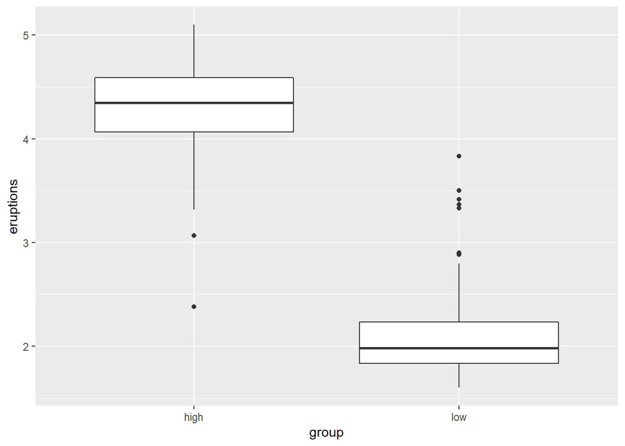

```r
# Your solution here
faithful_split%>%
  ggplot(aes(x = group,
             y = eruptions)) +
  geom_boxplot()
```

Also, try alternatives to boxplots such as the violin plot or `geom_quasirandom` (for the latter you have to install the `ggbeeswarm` package).

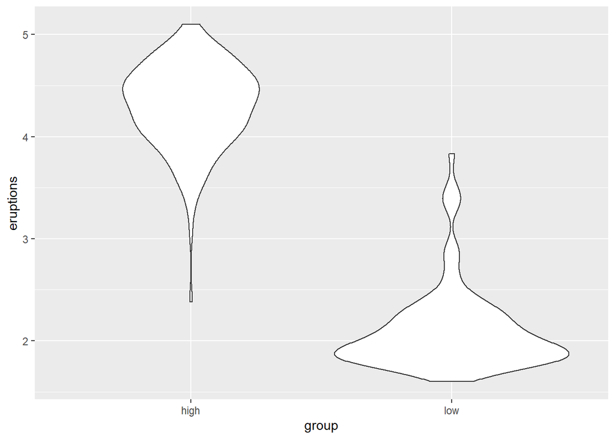

```r
# Put your alternative to the boxplot here.
faithful_split%>%
  ggplot(aes(x = group,
             y = eruptions)) +
  geom_violin()
```

Now plot 95% confidence intervals for the eruption times for the two groups. After that, change the confidence level and observe how the confidence intervals change.

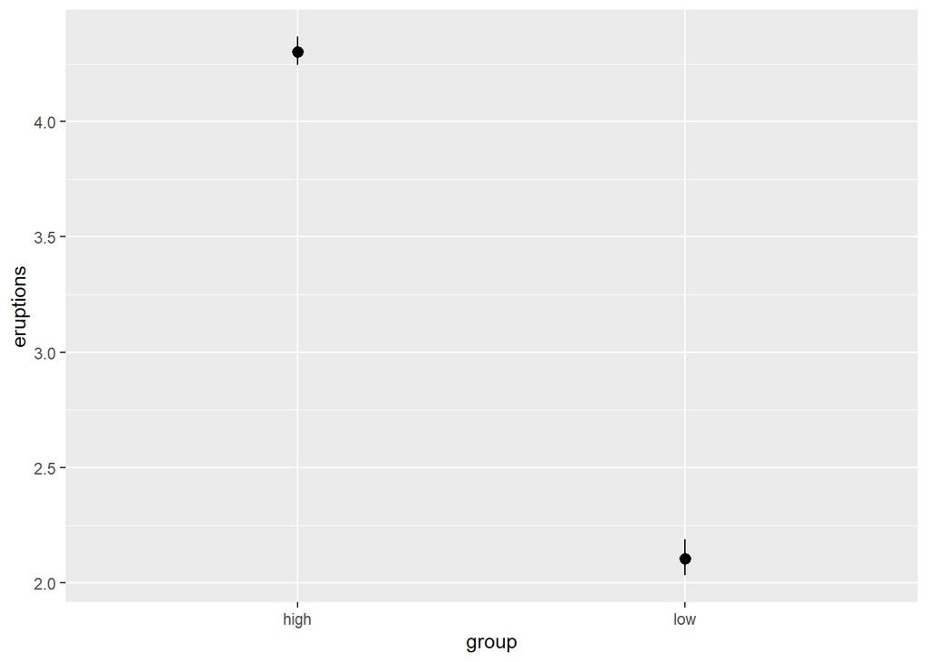

```r
# Plot confidence intervals here
faithful_split %>%
 ggplot(aes(x=group, y=eruptions)) +
  stat_summary(fun.data=mean_cl_boot, fun.args = list(conf.int=.95))
```

Finally, plot the two dimensional distribution of `eruptions` and `waiting` from the original `faithful` dataset, using `stat_density_2d_filled`. What can you observe in the resulting plot?

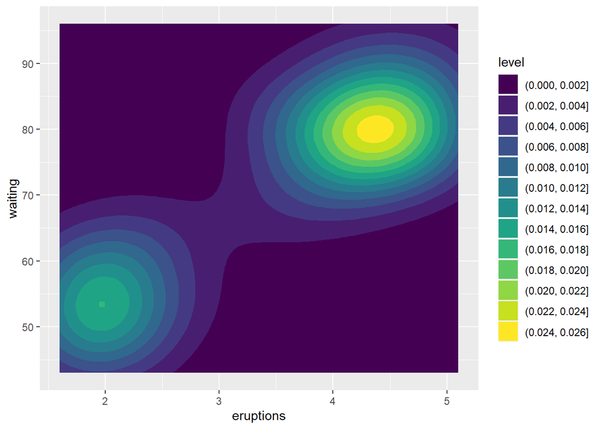

```r
# Your solution here
faithful %>%
  ggplot(aes(x = eruptions, y= waiting)) +
  stat_density2d_filled()
```